# Data624 - Homework4

Amit Kapoor

2/28/2021

```r
library(mlbench)
library(VIM)
library(DataExplorer)
library(GGally)
library(psych)
library(caret)
library(summarytools)
library(naniar)
library(dplyr)
library(Amelia)
```

## 3.1

**The UC Irvine Machine Learning Repository6 contains a data set related to glass identification. The data consist of 214 glass samples labeled as one of seven class categories. There are nine predictors, including the refractive index and percentages of eight elements: Na, Mg, Al, Si, K, Ca, Ba, and Fe.**

The data can be accessed via:

```r
# load Glass data
data(Glass)
str(Glass)
```

```
## 'data.frame':    214 obs. of  10 variables:
##  $ RI  : num  1.52 1.52 1.52 1.52 1.52 ...
##  $ Na  : num  13.6 13.9 13.5 13.2 13.3 ...
##  $ Mg  : num  4.49 3.6 3.55 3.69 3.62 3.61 3.6 3.61 3.58 3.6 ...
##  $ Al  : num  1.1 1.36 1.54 1.29 1.24 1.62 1.14 1.05 1.37 1.36 ...
##  $ Si  : num  71.8 72.7 73 72.6 73.1 ...
##  $ K   : num  0.06 0.48 0.39 0.57 0.55 0.64 0.58 0.57 0.56 0.57 ...
##  $ Ca  : num  8.75 7.83 7.78 8.22 8.07 8.07 8.17 8.24 8.3 8.4 ...
##  $ Ba  : num  0 0 0 0 0 0 0 0 0 0 ...
##  $ Fe  : num  0 0 0 0 0 0.26 0 0 0 0.11 ...
##  $ Type: Factor w/ 6 levels "1","2","3","5",..: 1 1 1 1 1 1 1 1 1 1 ...
```

### (a)

**Using visualizations, explore the predictor variables to understand their distributions as well as the relationships between predictors.**

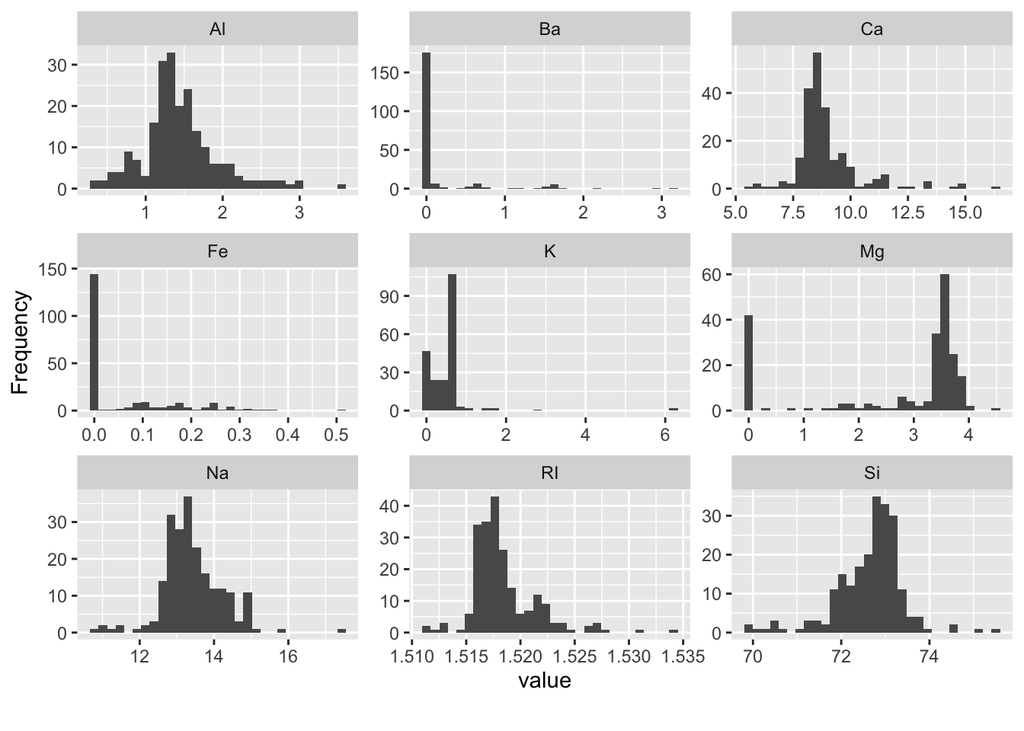

```r
# predictors distribution
plot_histogram(Glass,
               geom_histogram_args = list(bins = 30L),
               nrow = 3L,
               ncol = 3L)
```

The plots above represent the distribution of predictors in the data. They could be used to compare the distributions against the normal distribution.AI, Na, Si appears nearly normal distributed with slight skewness while Ba, Ca, Fe, k and RI are right skewed.

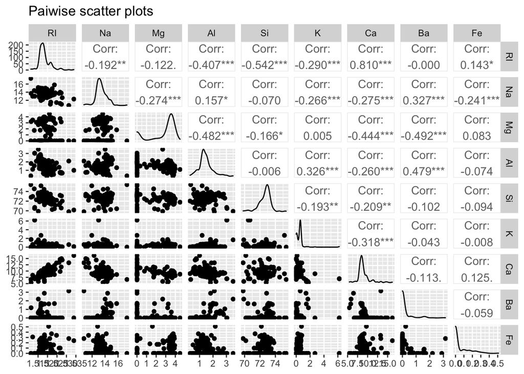

```r
# scatterplot matrix
Glass %>%
  dplyr::select(-Type) %>%
  ggpairs(title = "Paiwise scatter plots") %>%
  print(progress = F)
```

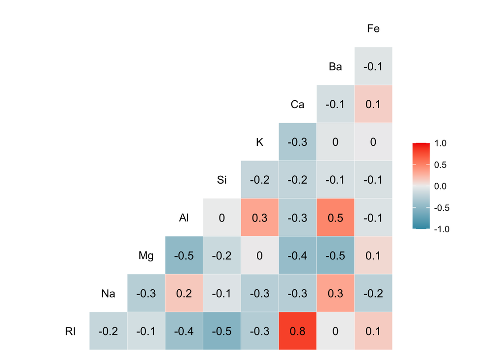

```r
# correlation
Glass %>%
  dplyr::select(-Type) %>%
  ggcorr(label = TRUE)
```

Above graphs depict the scatterplots and correlation among the predictors. It is evident that RI and Ca are strongly correlated. There are few other predictors having moderate correlation.

### (b)

**Do there appear to be any outliers in the data? Are any predictors skewed?**

```r
describe(Glass)
```

```
##       vars   n  mean   sd median trimmed  mad   min   max range  skew kurtosis
## RI       1 214  1.52 0.00   1.52    1.52 0.00  1.51  1.53  0.02  1.60     4.72
## Na       2 214 13.41 0.82  13.30   13.38 0.64 10.73 17.38  6.65  0.45     2.90
## Mg       3 214  2.68 1.44   3.48    2.87 0.30  0.00  4.49  4.49 -1.14    -0.45
## Al       4 214  1.44 0.50   1.36    1.41 0.31  0.29  3.50  3.21  0.89     1.94
## Si       5 214 72.65 0.77  72.79   72.71 0.57 69.81 75.41  5.60 -0.72     2.82
## K        6 214  0.50 0.65   0.56    0.43 0.17  0.00  6.21  6.21  6.46    52.87
## Ca       7 214  8.96 1.42   8.60    8.74 0.66  5.43 16.19 10.76  2.02     6.41
## Ba       8 214  0.18 0.50   0.00    0.03 0.00  0.00  3.15  3.15  3.37    12.08
## Fe       9 214  0.06 0.10   0.00    0.04 0.00  0.00  0.51  0.51  1.73     2.52
## Type*   10 214  2.54 1.71   2.00    2.31 1.48  1.00  6.00  5.00  1.04    -0.29
##         se
## RI    0.00
## Na    0.06
## Mg    0.10
## Al    0.03
## Si    0.05
## K     0.04
## Ca    0.10
## Ba    0.03
## Fe    0.01
## Type* 0.12
```

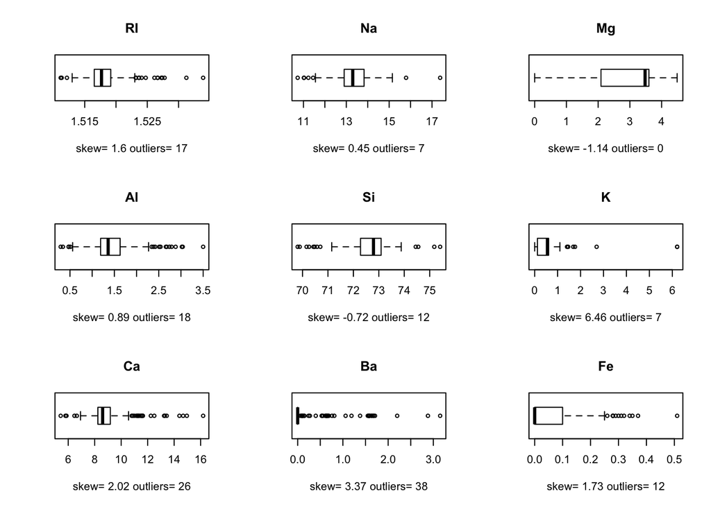

```r
# function to get skewness and number of outliers for given var
label <- function(var) {
  return( paste("skew=" , round(describe(var)$skew,2) , "outliers=" , length(boxplot(var, plot=FALSE)$out)) )
}

par(mfrow=c(3,3))
# draw boxplot of predictors
for (i in 1:9){
  boxplot(
    Glass[i],
    color='green',
    horizontal = T,
    main = names(Glass)[i],
    xlab = label(Glass[i])
    )
}
```

With these boxplots, we can see the skewness measure and number of outliers for all predictors in the data. Ba and Ca have most of the outliers. Also Mg doesn’t show up any outliers but its distribution seems left skewed.

### (c)

**Are there any relevant transformations of one or more predictors that might improve the classification model?**

As seen above, the variables in dataset are skewed so we will try the BoxCox transformation first to see if it improves them to an extent. Next we will try the transformation using BoxCox and PCA both if that makes any difference compared to the first one (with only BoxCox), The reason for using PCA is some variables showing correlations and we will see if PCA could improve that.

**BoxCox Transformation**

```r
# preprocess using BoxCox
glass_boxcox_t <- preProcess(Glass, method = c("BoxCox"))
glass_boxcox_t
```

[output not shown]

```r
# predict using boxcox transformation
trans_boxcox <- predict(glass_boxcox_t, Glass)
```

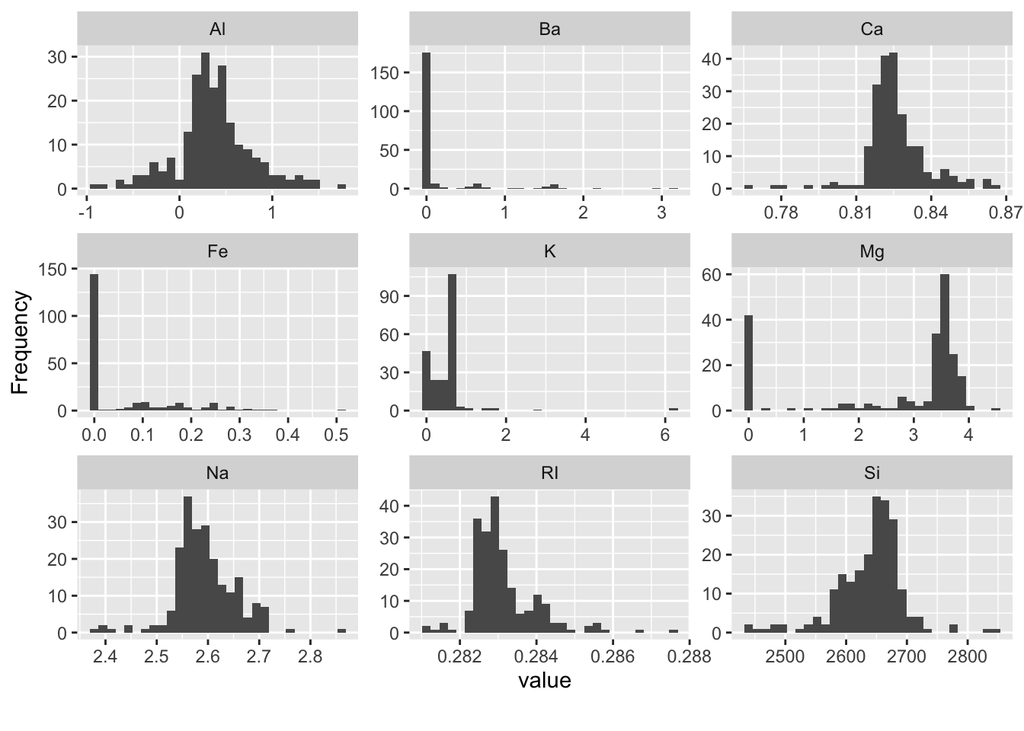

```r
# plot histogram
plot_histogram(trans_boxcox,
               geom_histogram_args = list(bins = 30L),
               nrow = 3L,
               ncol = 3L)
```

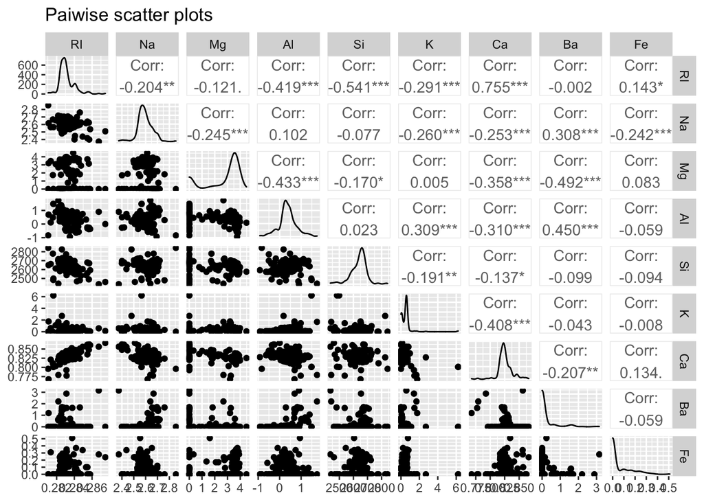

```r
# scatterplot matrix
trans_boxcox %>%
  dplyr::select(-Type) %>%
  ggpairs(title = "Paiwise scatter plots") %>%
  print(progress = F)
```

**BoxCox and PCA Transformation**

```r
glass_bcpca_t <- preProcess(Glass, method = c("BoxCox", "pca"))
glass_bcpca_t
```

```
## Created from 214 samples and 10 variables
##
## Pre-processing:
##   - Box-Cox transformation (5)
##   - centered (9)
##   - ignored (1)
##   - principal component signal extraction (9)
##   - scaled (9)
##
## Lambda estimates for Box-Cox transformation:
## -2, -0.1, 0.5, 2, -1.1
## PCA needed 7 components to capture 95 percent of the variance
```

```r
# predict with BoxCox and PCA transformation
trans_bcpca <- predict(glass_bcpca_t, Glass)
```

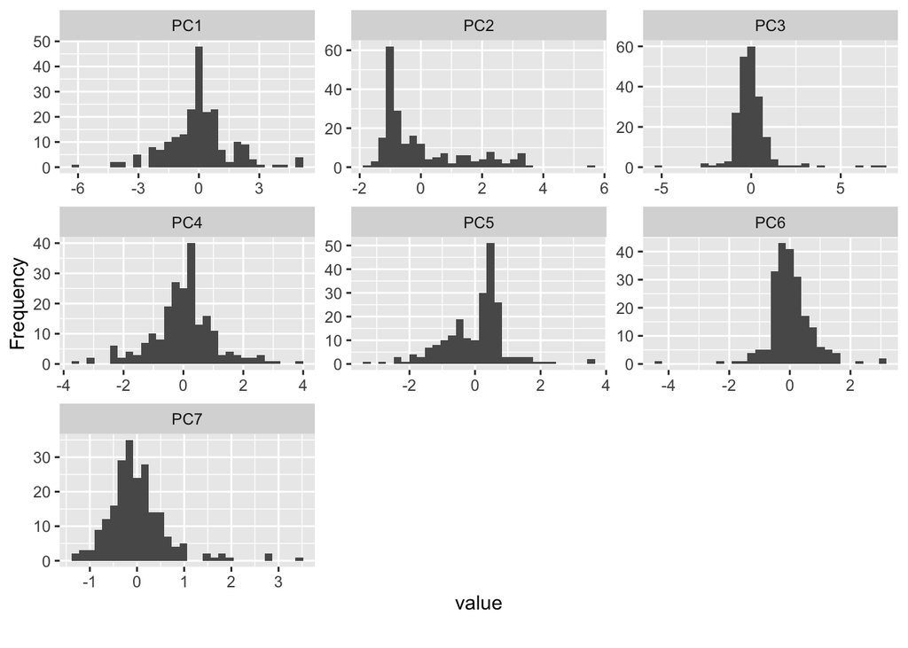

```r
# plot histogram
plot_histogram(trans_bcpca,
               geom_histogram_args = list(bins = 30L),
               nrow = 3L,
               ncol = 3L)
```

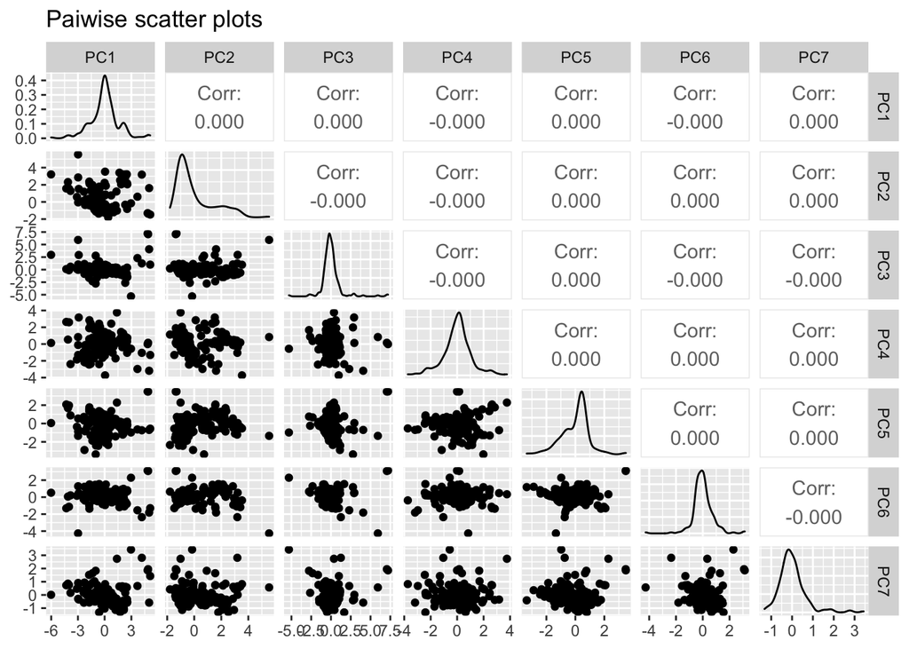

```r
# scatterplot matrix
trans_bcpca %>%
  dplyr::select(-Type) %>%
  ggpairs(title = "Paiwise scatter plots") %>%
  print(progress = F)
```

We see BoxCox+PCA transformation makes the result better as compared to BoxCox only. BoxCox and PCA transformation makes the distribution a lot better and more towards normal distribution. Also it is evident that now it doesnt show any correlation.

## 3.2

**The soybean data can also be found at the UC Irvine Machine Learning Repository. Data were collected to predict disease in 683 soybeans. The 35 predictors are mostly categorical and include information on the environmental conditions (e.g., temperature, precipitation) and plant conditions (e.g., left spots, mold growth). The outcome labels consist of 19 distinct classes.**

The data can be loaded via:

```r
data(Soybean)
str(Soybean)
```

```
## 'data.frame':    683 obs. of  36 variables:
##  $ Class          : Factor w/ 19 levels "2-4-d-injury",..: 11 11 11 11 11 11 11 11 11 11 ...
##  $ date           : Factor w/ 7 levels "0","1","2","3",..: 7 5 4 4 7 6 6 5 7 5 ...
##  $ plant.stand    : Ord.factor w/ 2 levels "0"<"1": 1 1 1 1 1 1 1 1 1 1 ...
##  $ precip         : Ord.factor w/ 3 levels "0"<"1"<"2": 3 3 3 3 3 3 3 3 3 3 ...
##  $ temp           : Ord.factor w/ 3 levels "0"<"1"<"2": 2 2 2 2 2 2 2 2 2 2 ...
##  $ hail           : Factor w/ 2 levels "0","1": 1 1 1 1 1 1 1 2 1 1 ...
##  $ crop.hist      : Factor w/ 4 levels "0","1","2","3": 2 3 2 2 3 4 3 2 4 3 ...
##  $ area.dam       : Factor w/ 4 levels "0","1","2","3": 2 1 1 1 1 1 1 1 1 1 ...
##  $ sever          : Factor w/ 3 levels "0","1","2": 2 3 3 3 2 2 2 2 2 3 ...
##  $ seed.tmt       : Factor w/ 3 levels "0","1","2": 1 2 2 1 1 1 2 1 2 1 ...
##  $ germ           : Ord.factor w/ 3 levels "0"<"1"<"2": 1 2 3 2 3 2 1 3 2 3 ...
##  $ plant.growth   : Factor w/ 2 levels "0","1": 2 2 2 2 2 2 2 2 2 2 ...
##  $ leaves         : Factor w/ 2 levels "0","1": 2 2 2 2 2 2 2 2 2 2 ...
##  $ leaf.halo      : Factor w/ 3 levels "0","1","2": 1 1 1 1 1 1 1 1 1 1 ...
```

[output cut: 22 more lines]

### (a)

**Investigate the frequency distributions for the categorical predictors. Are any of the distributions degenerate in the ways discussed earlier in this chapter?**

```r
# summary
dfSummary(Soybean, graph.col = F)
```

```
## Data Frame Summary
## Soybean
## Dimensions: 683 x 36
## Duplicates: 52
##
## ----------------------------------------------------------------------------------------------------
## No   Variable            Stats / Values                    Freqs (% of Valid)   Valid      Missing
## ---- ------------------- --------------------------------- -------------------- ---------- ---------
## 1    Class               1. 2-4-d-injury                    16 ( 2.3%)          683        0
##      [factor]            2. alternarialeaf-spot             91 (13.3%)          (100.0%)   (0.0%)
##                          3. anthracnose                     44 ( 6.4%)
##                          4. bacterial-blight                20 ( 2.9%)
##                          5. bacterial-pustule               20 ( 2.9%)
##                          6. brown-spot                      92 (13.5%)
##                          7. brown-stem-rot                  44 ( 6.4%)
##                          8. charcoal-rot                    20 ( 2.9%)
##                          9. cyst-nematode                   14 ( 2.0%)
##                          10. diaporthe-pod-&-stem-blig      15 ( 2.2%)
##                          [ 9 others ]                      307 (44.9%)
##
## 2    date                1. 0                               26 ( 3.8%)          682        1
##      [factor]            2. 1                               75 (11.0%)          (99.9%)    (0.1%)
##                          3. 2                               93 (13.6%)
##                          4. 3                              118 (17.3%)
##                          5. 4                              131 (19.2%)
##                          6. 5                              149 (21.8%)
##                          7. 6                               90 (13.2%)
##
## 3    plant.stand         1. 0                              354 (54.7%)          647        36
##      [ordered, factor]   2. 1                              293 (45.3%)          (94.7%)    (5.3%)
##
## 4    precip              1. 0                               74 (11.5%)          645        38
##      [ordered, factor]   2. 1                              112 (17.4%)          (94.4%)    (5.6%)
##                          3. 2                              459 (71.2%)
##
## 5    temp                1. 0                               80 (12.3%)          653        30
##      [ordered, factor]   2. 1                              374 (57.3%)          (95.6%)    (4.4%)
##                          3. 2                              199 (30.5%)
##
## 6    hail                1. 0                              435 (77.4%)          562        121
```

[output cut: 99 more lines]

```
##      [factor]            2. 1                               67 (11.3%)          (86.5%)    (13.5%)
##
## 33   seed.discolor       1. 0                              513 (88.9%)          577        106
##      [factor]            2. 1                               64 (11.1%)          (84.5%)    (15.5%)
##
## 34   seed.size           1. 0                              532 (90.0%)          591        92
##      [factor]            2. 1                               59 (10.0%)          (86.5%)    (13.5%)
##
## 35   shriveling          1. 0                              539 (93.4%)          577        106
##      [factor]            2. 1                               38 ( 6.6%)          (84.5%)    (15.5%)
##
## 36   roots               1. 0                              551 (84.5%)          652        31
##      [factor]            2. 1                               86 (13.2%)          (95.5%)    (4.5%)
##                          3. 2                               15 ( 2.3%)
## ----------------------------------------------------------------------------------------------------
```

This tables shows the frequesncy distribution of Soybean dataset. The data has 683 rows and 36 variables. There are 35 predictors in the data and ‘Class’ is the response variable. There are 19 classes for response variable ‘Class’. All predictors are numeric categorical variables.

From [link](https://www.statisticshowto.com/degenerate-distribution/), A degenerate distribution (sometimes called a constant distribution) is a distribution of a degenerate random variable — a constant with probability of 1. In other words, a random variable X has a single possible value. In other words, A random variable, X, is degenerate if, for some a constant, c, P(X = c) = 1.

The nearZeroVar function could be used to find the degenrate variables here.

```r
# find degenerate vars
nzvs <- nearZeroVar(Soybean)
names(Soybean)[nzvs]
```

```
## [1] "leaf.mild" "mycelium"  "sclerotia"
```

### (b)

**Roughly 18% of the data are missing. Are there particular predictors that are more likely to be missing? Is the pattern of missing data related to the classes?**

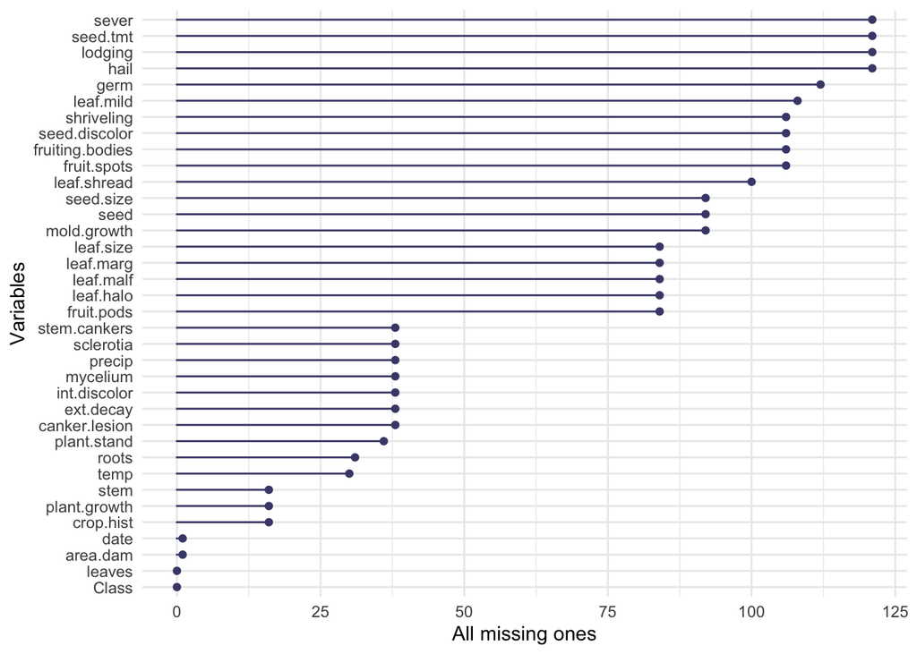

```r
gg_miss_var(Soybean) + labs(y = "All missing ones")
```

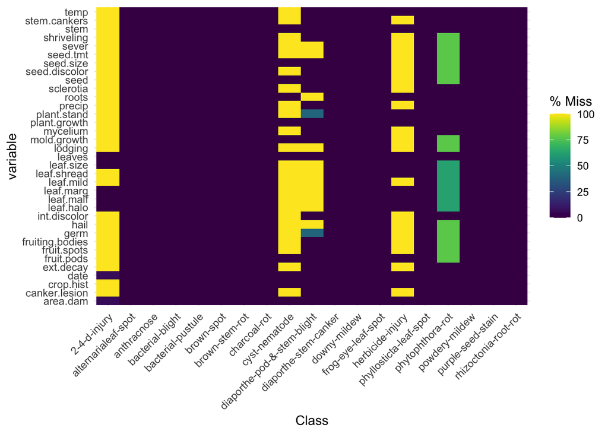

```r
gg_miss_fct(x=Soybean, fct=Class)
```

Based on above graphs, the predictors having most of the missing values are sever, seed.tmt, lodging and hall. Also within Class response variable, it seems like most of the missing data is in ‘phytophthora-rot’ followed by ‘2-4-d-injury’. The most common one between all these NA’s is cyst-nematode. Looking at the NA’s, there seems to be a pattern appearing as few numbers are getting repeated like sever, seed.tmt, lodging and hall, are missing 121 values.

```r
# incomplete cases by Class variable
Soybean[which(!complete.cases(Soybean)),] %>%
  group_by(Class) %>%
  summarise(Count = n())
```

```
## # A tibble: 5 x 2
##   Class                       Count
## * <fct>                       <int>
## 1 2-4-d-injury                   16
## 2 cyst-nematode                  14
## 3 diaporthe-pod-&-stem-blight    15
## 4 herbicide-injury                8
## 5 phytophthora-rot               68
```

### (c)

**Develop a strategy for handling missing data, either by eliminating predictors or imputation.**

```r
Soybean_final <- Soybean %>%
  select(-leaf.mild, -mycelium, -sclerotia) %>% kNN()
```

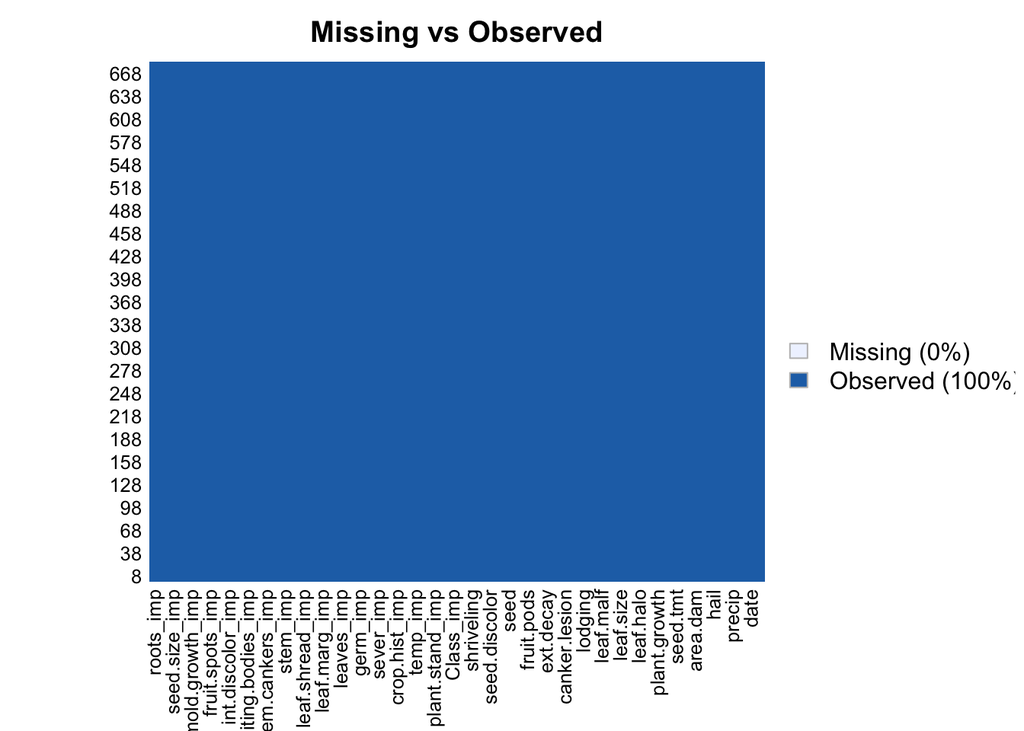

```r
Soybean_final %>%
  arrange(Class) %>%
  missmap(main = "Missing vs Observed")
```